# Classification

Nirzaree

09/07/2020

## Goal: Understand classification concepts with examples

## Theory

- What is classification? A technique applied to estimate categorical output variable
- What types of classification techniques exist?
  - Binary
  - Multiclass
- (A few) Classification algorithms
  - Decision Trees
  - Linear Discriminant Analysis (LDA)
  - Random forest
  - Support Vector Machine (SVM)
  - k-nearest neighbors (kNN)
  - Naive Bayes
- Assumptions of classification None that I can think of
- Preprocessing for classification
- Feature Engineering for classification
- Tuning a classification model
- Metrics for evaluating a classification model
  - Binary Classifier:
    - Confusion matrix
    - AUC-ROC Curve
    - Precision, Recall
    - Sensitivity, Specificity
  - Multiclass Classifier:

We now look at a couple of datasets

## Iris

```
Dataset description: Edgar Anderson's Iris Data

This famous (Fisher's or Anderson's) iris data set gives the measurements in centimeters of the variables sepal length and width and petal length and width, respectively, for 50 flowers from each of 3 species of iris. The species are Iris setosa, versicolor, and virginica.

iris is a data frame with 150 cases (rows) and 5 variables (columns) named Sepal.Length, Sepal.Width, Petal.Length, Petal.Width, and Species.

Task: Classification of iris species from the sepal & petal length and width features.
```

### 1. Load Data

```
##   Sepal.Length    Sepal.Width     Petal.Length    Petal.Width
##  Min.   :4.300   Min.   :2.000   Min.   :1.000   Min.   :0.100
##  1st Qu.:5.100   1st Qu.:2.800   1st Qu.:1.600   1st Qu.:0.300
##  Median :5.800   Median :3.000   Median :4.350   Median :1.300
##  Mean   :5.843   Mean   :3.057   Mean   :3.758   Mean   :1.199
##  3rd Qu.:6.400   3rd Qu.:3.300   3rd Qu.:5.100   3rd Qu.:1.800
##  Max.   :7.900   Max.   :4.400   Max.   :6.900   Max.   :2.500
##        Species
##  setosa    :50
##  versicolor:50
##  virginica :50
##
##
##
```

### 2. Feature Exploration

A couple of different ways of feature plots: i) pair plot ii) box plot iii) density plot

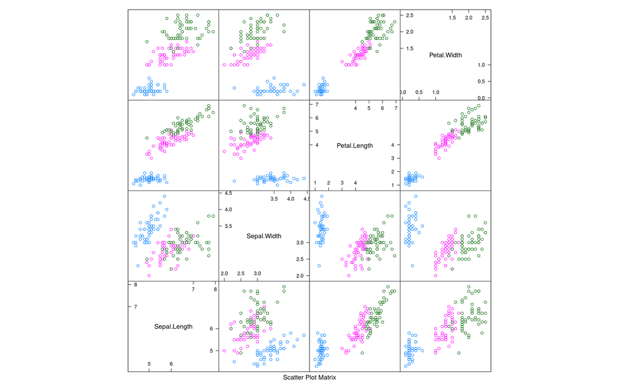

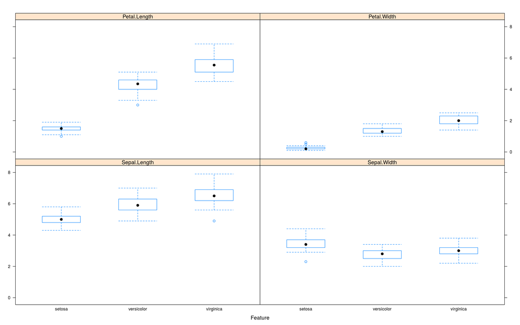

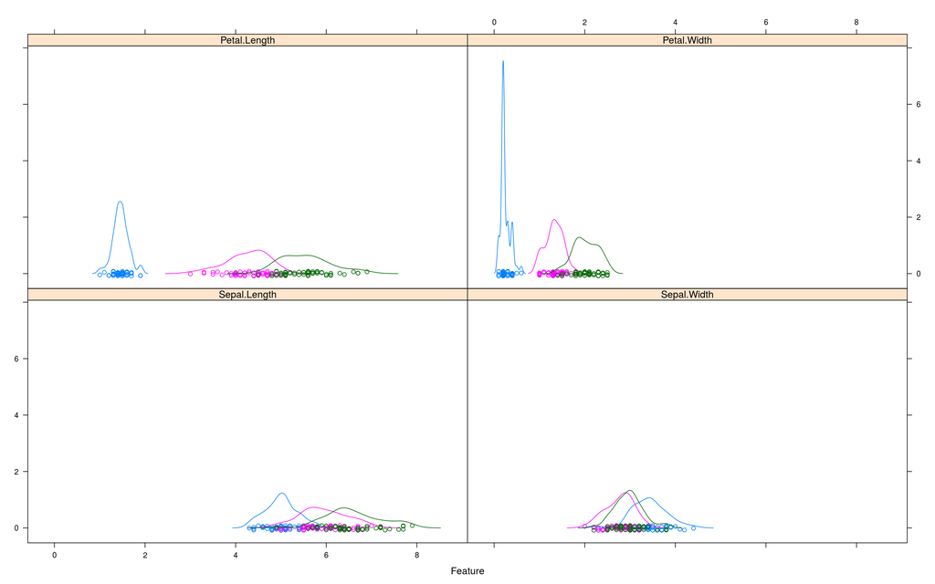

**Observation**: Petal Width & Length are good features. Sepal length okayish and sepal width not good.